# Hierarchy Experiment: Descriptive statistics

Bodo Winter (statistical analysis)

7/17/2019

## Introduction

This is the statistical analysis of our “hierarchy experiment”, a replication-extension of Schubert’s (2005) study which associates vertical positions with power. The present study includes the added dimension of gender.

This script performs descriptive statistics and plotting.

## Preprocessing

Load stuff:

```r
# Packages:

library(tidyverse)
library(gridExtra)

# Data:

power <- read_csv('data/hierarchy_experiment_cleaned.csv')

# ggplot2 theme:

source('timo_theme.R')
```

## Demographics to report

Overall number of participants to report:

```r
length(unique(power$Subj))
```

```
## [1] 62
```

Check gender composition:

```r
# Create a table with subject identifiers by gender:

gender_tab <- table(power$Subj, power$SubjGender)

# Check 0 counts to get number of genders:

genders <- apply(gender_tab, 1, FUN = function(x) ifelse(x[1] == 0, 'male', 'female'))

# How many each?

table(genders)
```

```
## genders
## female   male
##     51     11
```

## Compute averages:

First, overall response times:

```r
power %>% summarize(M = round(mean(RT), 0),
                    SD = round(sd(RT), 0))
```

```
## # A tibble: 1 x 2
##       M    SD
##   <dbl> <dbl>
## 1  1790   707
```

Next by overall participant gender:

```r
power %>% group_by(SubjGender) %>%
  summarize(M = round(mean(RT), 0),
            SD = round(sd(RT), 0))
```

```
## # A tibble: 2 x 3
##   SubjGender     M    SD
##   <chr>      <dbl> <dbl>
## 1 female      1809   722
## 2 male        1705   628
```

Next by overall hierarchy condition:

```r
power %>% group_by(HierarchyCond) %>%
  summarize(M = round(mean(RT), 0),
            SD = round(sd(RT), 0))
```

```
## # A tibble: 2 x 3
##   HierarchyCond     M    SD
##   <chr>         <dbl> <dbl>
## 1 BottomPower    1797   708
## 2 TopPower       1784   707
```

Next by gender condition:

```r
power %>% group_by(GenderCond) %>%
  summarize(M = round(mean(RT), 0),
            SD = round(sd(RT), 0))
```

```
## # A tibble: 2 x 3
##   GenderCond     M    SD
##   <chr>      <dbl> <dbl>
## 1 FemaleTop   1784   698
## 2 MaleTop     1797   717
```

Next by gender and hierarchy condition:

```r
power %>% group_by(GenderCond, HierarchyCond) %>%
  summarize(M = round(mean(RT), 0),
            SD = round(sd(RT), 0))
```

```
## # A tibble: 4 x 4
## # Groups:   GenderCond [2]
##   GenderCond HierarchyCond     M    SD
##   <chr>      <chr>         <dbl> <dbl>
## 1 FemaleTop  BottomPower    1771   694
## 2 FemaleTop  TopPower       1797   701
## 3 MaleTop    BottomPower    1823   721
## 4 MaleTop    TopPower       1771   712
```

Looks like an interaction. When the woman is on top peple are SLOWER if the woman is also more powerful. When the man is on top, people are FASTER if the man is also more powerful. The slowest response times are obtained for when the man is on top but the more powerful position is female and at the bottom.

Another way to look at these results is to focus on the one where the bottom position is the more powerful one (HierarchyCond = “BottomPower”). In that case, people are faster when the man is the more powerful.

Another way to look at this, whether people find it overall easier/harder if male = powerful:

```r
power %>% group_by(GenderPower) %>%
  summarize(M = round(mean(RT), 0),
            SD = round(sd(RT), 0))
```

```
## # A tibble: 2 x 3
##   GenderPower         M    SD
##   <chr>           <dbl> <dbl>
## 1 female=powerful  1810   711
## 2 male=powerful    1771   703
```

People are faster in the male = powerful condition.

Let’s break this up by hierarchy condition (verticality):

```r
power %>% group_by(GenderPower, HierarchyCond) %>%
  summarize(M = round(mean(RT), 0),
            SD = round(sd(RT), 0))
```

```
## # A tibble: 4 x 4
## # Groups:   GenderPower [2]
##   GenderPower     HierarchyCond     M    SD
##   <chr>           <chr>         <dbl> <dbl>
## 1 female=powerful BottomPower    1823   721
## 2 female=powerful TopPower       1797   701
## 3 male=powerful   BottomPower    1771   694
## 4 male=powerful   TopPower       1771   712
```

Let’s break this up by task:

```r
power %>% group_by(Task) %>%
  summarize(M = round(mean(RT), 0),
            SD = round(sd(RT), 0))
```

```
## # A tibble: 2 x 3
##   Task          M    SD
##   <chr>     <dbl> <dbl>
## 1 powerful   1628   634
## 2 powerless  1960   739
```

Let’s see whether the hierarchy condition interacts with Task:

```r
power %>% group_by(Task, HierarchyCond) %>%
  summarize(M = round(mean(RT), 0),
            SD = round(sd(RT), 0))
```

```
## # A tibble: 4 x 4
## # Groups:   Task [2]
##   Task      HierarchyCond     M    SD
##   <chr>     <chr>         <dbl> <dbl>
## 1 powerful  BottomPower    1627   629
## 2 powerful  TopPower       1629   640
## 3 powerless BottomPower    1976   742
## 4 powerless TopPower       1945   737
```

When participants are picking the powerful one, they are faster with the bottom being at the powerful position. This goes against Schubert (2005). When participants are picking the powerless one, there is a slight effect in the predicted direction with the top = powerful being slightly faster.

Let’s look at task and gender:

```r
power %>% group_by(Task, GenderCond) %>%
  summarize(M = round(mean(RT), 0),
            SD = round(sd(RT), 0))
```

```
## # A tibble: 4 x 4
## # Groups:   Task [2]
##   Task      GenderCond     M    SD
##   <chr>     <chr>      <dbl> <dbl>
## 1 powerful  FemaleTop   1628   623
## 2 powerful  MaleTop     1628   646
## 3 powerless FemaleTop   1945   734
## 4 powerless MaleTop     1976   744
```

Let’s look at the double match variable:

```r
power %>% group_by(DoubleMatch) %>%
  summarize(M = round(mean(RT), 0),
            SD = round(sd(RT), 0))
```

```
## # A tibble: 2 x 3
##   DoubleMatch              M    SD
##   <chr>                <dbl> <dbl>
## 1 male powerful on top  1771   712
## 2 no match              1797   706
```

Let’s look at this as a function of task:

```r
power %>% group_by(Task, DoubleMatch) %>%
  summarize(M = round(mean(RT), 0),
            SD = round(sd(RT), 0))
```

```
## # A tibble: 4 x 4
## # Groups:   Task [2]
##   Task      DoubleMatch              M    SD
##   <chr>     <chr>                <dbl> <dbl>
## 1 powerful  male powerful on top  1621   651
## 2 powerful  no match              1631   629
## 3 powerless male powerful on top  1930   739
## 4 powerless no match              1971   739
```

Let’s break this up by participant gender:

```r
power %>% group_by(SubjGender, DoubleMatch) %>%
  summarize(M = round(mean(RT), 0),
            SD = round(sd(RT), 0))
```

```
## # A tibble: 4 x 4
## # Groups:   SubjGender [2]
##   SubjGender DoubleMatch              M    SD
##   <chr>      <chr>                <dbl> <dbl>
## 1 female     male powerful on top  1801   724
## 2 female     no match              1812   721
## 3 male       male powerful on top  1637   639
## 4 male       no match              1729   623
```

Massive difference where the male participants are showing a 100 ms drop if the men is powerful and on top!

Are people overall faster when they have to pick the male response or when they have to pick the female response?

```r
power %>% group_by(PickedGender) %>%
  summarize(M = round(mean(RT), 0),
            SD = round(sd(RT), 0))
```

```
## # A tibble: 2 x 3
##   PickedGender     M    SD
##   <chr>        <dbl> <dbl>
## 1 female        1810   711
## 2 male          1771   703
```

Overall faster selecting the male.

Does this differ by subject gender?

```r
power %>% group_by(SubjGender, PickedGender) %>%
  summarize(M = round(mean(RT), 0),
            SD = round(sd(RT), 0))
```

```
## # A tibble: 4 x 4
## # Groups:   SubjGender [2]
##   SubjGender PickedGender     M    SD
##   <chr>      <chr>        <dbl> <dbl>
## 1 female     female        1816   726
## 2 female     male          1802   719
## 3 male       female        1781   639
## 4 male       male          1632   610
```

The men are overall faster at picking the male response. The women have the same directional preference, but less pronounced.

```r
power %>% group_by(SubjGender,
                   Task, PickedGender) %>%
  summarize(M = round(mean(RT), 0),
            SD = round(sd(RT), 0))
```

```
## # A tibble: 8 x 5
## # Groups:   SubjGender, Task [4]
##   SubjGender Task      PickedGender     M    SD
##   <chr>      <chr>     <chr>        <dbl> <dbl>
## 1 female     powerful  female        1631   659
## 2 female     powerful  male          1648   664
## 3 female     powerless female        1999   742
## 4 female     powerless male          1956   738
## 5 male       powerful  female        1660   526
## 6 male       powerful  male          1512   490
## 7 male       powerless female        1946   736
## 8 male       powerless male          1794   710
```

How does the hierarchy effect depend on subject gender?

```r
power %>% group_by(SubjGender, HierarchyCond) %>%
  summarize(M = round(mean(RT), 0),
            SD = round(sd(RT), 0))
```

```
## # A tibble: 4 x 4
## # Groups:   SubjGender [2]
##   SubjGender HierarchyCond     M    SD
##   <chr>      <chr>         <dbl> <dbl>
## 1 female     BottomPower    1815   722
## 2 female     TopPower       1803   722
## 3 male       BottomPower    1712   630
## 4 male       TopPower       1699   627
```

```r
power %>% group_by(SubjGender, GenderCond) %>%
  summarize(M = round(mean(RT), 0),
            SD = round(sd(RT), 0))
```

```
## # A tibble: 4 x 4
## # Groups:   SubjGender [2]
##   SubjGender GenderCond     M    SD
##   <chr>      <chr>      <dbl> <dbl>
## 1 female     FemaleTop   1804   717
## 2 female     MaleTop     1815   728
## 3 male       FemaleTop   1695   597
## 4 male       MaleTop     1716   659
```

## By-item averages:

Look at how the gender effect differs by item:

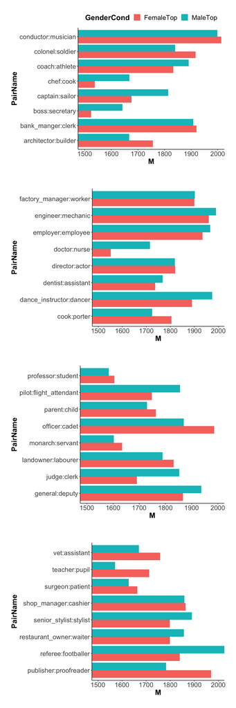

```r
item_gender <- power %>%
  group_by(PairName, GenderCond) %>%
  summarize(M = round(mean(RT), 0),
            SD = round(sd(RT), 0))

item_gender$Facet <- rep(str_c('Group', 1:4),
                         each = 16)

p1 <- item_gender %>%
  filter(Facet == 'Group1') %>%
  ggplot(aes(x = PairName,
             fill = GenderCond, y = M)) +
  geom_bar(stat = 'identity', position = 'dodge') +
  coord_flip(ylim = c(1500, 2000)) +
  theme_bham_stats +
  theme(legend.position = 'top')
p2 <- item_gender %>%
  filter(Facet == 'Group2') %>%
  ggplot(aes(x = PairName,
             fill = GenderCond, y = M)) +
  geom_bar(stat = 'identity', position = 'dodge') +
  coord_flip(ylim = c(1500, 2000)) +
  theme_bham_stats +
  theme(legend.position = 'none')
p3 <- item_gender %>%
  filter(Facet == 'Group3') %>%
  ggplot(aes(x = PairName,
             fill = GenderCond, y = M)) +
  geom_bar(stat = 'identity', position = 'dodge') +
  coord_flip(ylim = c(1500, 2000)) +
  theme_bham_stats +
  theme(legend.position = 'none')
p4 <- item_gender %>%
  filter(Facet == 'Group4') %>%
  ggplot(aes(x = PairName,
             fill = GenderCond, y = M)) +
  geom_bar(stat = 'identity', position = 'dodge') +
  coord_flip(ylim = c(1500, 2000)) +
  theme_bham_stats +
  theme(legend.position = 'none')
grid.arrange(p1, p2, p3, p4, nrow = 4, ncol = 1)
```

Look at how the hierarchy effect differs by item:

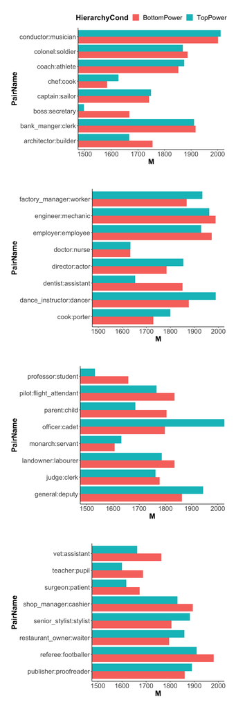

```r
item_hierarchy <- power %>%
  group_by(PairName, HierarchyCond) %>%
  summarize(M = round(mean(RT), 0),
            SD = round(sd(RT), 0))

item_hierarchy$Facet <- rep(str_c('Group', 1:4),
                         each = 16)

p1 <- item_hierarchy %>%
  filter(Facet == 'Group1') %>%
  ggplot(aes(x = PairName,
             fill = HierarchyCond, y = M)) +
  geom_bar(stat = 'identity', position = 'dodge') +
  coord_flip(ylim = c(1500, 2000)) +
  theme_bham_stats +
  theme(legend.position = 'top')
p2 <- item_hierarchy %>%
  filter(Facet == 'Group2') %>%
  ggplot(aes(x = PairName,
             fill = HierarchyCond, y = M)) +
  geom_bar(stat = 'identity', position = 'dodge') +
  coord_flip(ylim = c(1500, 2000)) +
  theme_bham_stats +
  theme(legend.position = 'none')
p3 <- item_hierarchy %>%
  filter(Facet == 'Group3') %>%
  ggplot(aes(x = PairName,
             fill = HierarchyCond, y = M)) +
  geom_bar(stat = 'identity', position = 'dodge') +
  coord_flip(ylim = c(1500, 2000)) +
  theme_bham_stats +
  theme(legend.position = 'none')
p4 <- item_hierarchy %>%
  filter(Facet == 'Group4') %>%
  ggplot(aes(x = PairName,
             fill = HierarchyCond, y = M)) +
  geom_bar(stat = 'identity', position = 'dodge') +
  coord_flip(ylim = c(1500, 2000)) +
  theme_bham_stats +
  theme(legend.position = 'none')
grid.arrange(p1, p2, p3, p4, nrow = 4, ncol = 1)
```

## Visualizations

First, the effect of picking the male response:

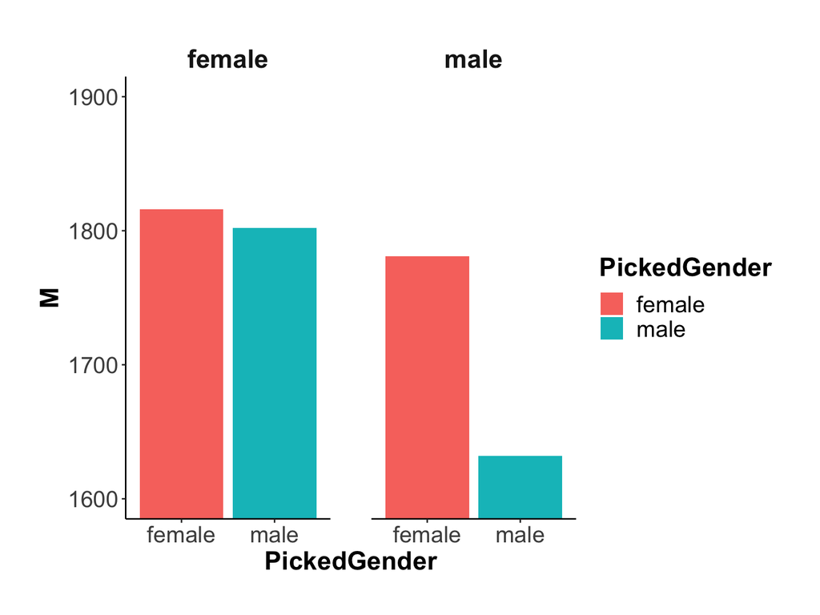

```r
power %>%
  group_by(SubjGender, PickedGender) %>%
  summarize(M = round(mean(RT), 0),
            SD = round(sd(RT), 0)) %>%
  ggplot(aes(x = PickedGender, fill = PickedGender, y = M)) +
  geom_bar(stat = 'identity') +
  facet_wrap(~SubjGender) +
  coord_cartesian(ylim = c(1600, 1900)) +
  theme_bham_stats
```

Second, the hierarchy effect:

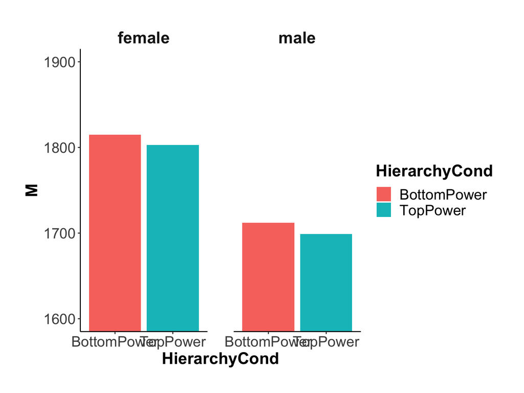

```r
power %>%
  group_by(SubjGender, HierarchyCond) %>%
  summarize(M = round(mean(RT), 0),
            SD = round(sd(RT), 0)) %>%
  ggplot(aes(x = HierarchyCond, fill = HierarchyCond, y = M)) +
  geom_bar(stat = 'identity') +
  facet_wrap(~SubjGender) +
  coord_cartesian(ylim = c(1600, 1900)) +
  theme_bham_stats
```

Third, the gender condition effect:

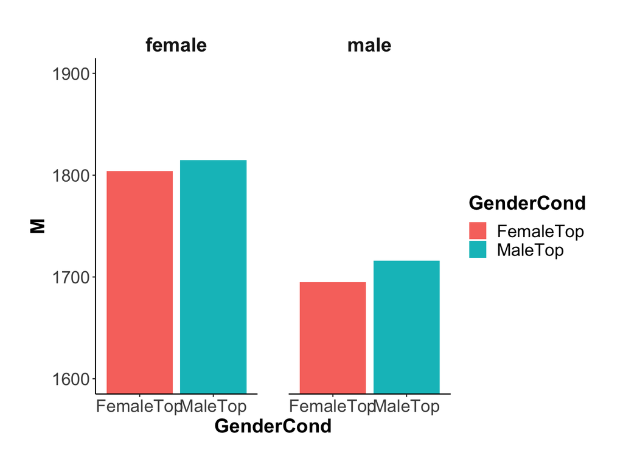

```r
power %>%
  group_by(SubjGender, GenderCond) %>%
  summarize(M = round(mean(RT), 0),
            SD = round(sd(RT), 0)) %>%
  ggplot(aes(x = GenderCond, fill = GenderCond, y = M)) +
  geom_bar(stat = 'identity') +
  facet_wrap(~SubjGender) +
  coord_cartesian(ylim = c(1600, 1900)) +
  theme_bham_stats
```

This completes this script.